# Italy Education Fiscal Landscape

This notebook consolidates the current fiscal evidence on Italy's education system into one reproducible analytical surface. It combines macro public and private spending, school-ledger proxies, level-aware institutional finance, household cost burden, tertiary support, and territorial funding-risk proxies.

## Source reliability rule

- Main fiscal analysis uses locally processed OECD, World Bank, Eurostat, SIOPE, MUR, MIM, and DSU outputs.
- Save the Children indicators are split by validation tier. Only indicators reproducible from local INVALSI or ISTAT files are treated as validated. PDF-only claims remain quarantined and are not mixed into the main fiscal evidence.

```python
from pathlib import Path
import numpy as np
import pandas as pd
import matplotlib.pyplot as plt
import seaborn as sns

sns.set_theme(style='whitegrid', palette='deep')
pd.set_option('display.max_columns', 100)
pd.set_option('display.float_format', lambda x: f'{x:,.2f}')

ROOT = Path.cwd().parents[0] if Path.cwd().name == 'Notebooks' else Path.cwd()
LOCAL = ROOT / 'local_data'
PROC = LOCAL / 'processed'
INVALSI = LOCAL / 'INVALSI'
EUROSTAT = LOCAL / 'eurostat'
ISTAT = LOCAL / 'ISTAT'

def pct_to_float(series: pd.Series) -> pd.Series:
    return pd.to_numeric(series.astype(str).str.replace(',', '.', regex=False).str.strip(), errors='coerce')

def bn(series: pd.Series) -> pd.Series:
    return series / 1_000_000_000

print('ROOT:', ROOT)
print('Processed outputs:', PROC.exists())
```

```
ROOT: c:\Users\Dell\Documents\VSC Projects\Italienation
Processed outputs: True
```

```python
inventory = pd.read_csv(PROC / 'education_fiscal_inventory.csv')
history = pd.read_csv(PROC / 'italy_education_expenditure_history_panel.csv')
finance = pd.read_csv(PROC / 'italy_education_finance_levels_real.csv')
household = pd.read_csv(PROC / 'italy_household_burden_module.csv')
territorial = pd.read_csv(PROC / 'italy_education_territorial_proxy_panel.csv')
save_children_pdf = pd.read_csv(PROC / 'save_the_children_italy_school_stats.csv')

invalsi_trend = pd.read_csv(INVALSI / 'dati-sottostanti-le-dashboard-di-tableau-del-rapporto-2023-2024-grado-8-grado-13__trend_traguardi_ms2024-dati-pop-g08-e-g13-2.csv', sep=';')
for col in ['Perc.2018', 'Perc.2019', 'Perc.2021', 'Perc.2022', 'Perc.2023', 'Perc.2024']:
    invalsi_trend[col] = pct_to_float(invalsi_trend[col])

istat_esl = pd.read_csv(ISTAT / 'istat_early_school_leavers.csv')

print('Inventory rows:', len(inventory))
print('History rows:', len(history))
print('Finance rows:', len(finance))
print('Household rows:', len(household))
print('Territorial rows:', len(territorial))
print('Save the Children PDF rows:', len(save_children_pdf))
```

```
Inventory rows: 39
History rows: 50
Finance rows: 39
Household rows: 19
Territorial rows: 18
Save the Children PDF rows: 5
```

## 1. System-Wide Fiscal Burden

This section focuses on the macro history: total public education spending as a share of GDP, public spending as a share of total government expenditure, and the OECD split between state funding and household or private funding.

|  | year | public_pct_gdp_owid | public_pct_govexp_owid | state_pct_gdp | parents_private_pct_gdp | total_pct_gdp | state_share_of_total_pct | parents_private_share_of_total_pct | state_usd_ppp | parents_private_usd_ppp | total_usd_ppp | siope_school_expenditure_eur | siope_school_count | siope_series_note |
| --- | --- | --- | --- | --- | --- | --- | --- | --- | --- | --- | --- | --- | --- | --- |
| 40 | 2017 | 4.04 | 7.92 | 3.31 | 0.47 | 3.83 | 86.32 | 12.36 | 94,722.08 | 13,564.10 | 109,731.03 | NaN | NaN | NaN |
| 41 | 2018 | 4.26 | 8.11 | 3.47 | 0.57 | 4.08 | 85.07 | 13.91 | 100,214.10 | 16,383.61 | 117,804.85 | NaN | NaN | NaN |
| 42 | 2019 | 4.10 | 8.05 | 3.30 | 0.51 | 3.83 | 86.07 | 13.33 | 95,631.48 | 14,806.21 | 111,110.42 | NaN | NaN | NaN |
| 43 | 2020 | 4.44 | 7.49 | 3.62 | 0.51 | 4.16 | 86.85 | 12.33 | 95,494.41 | 13,558.47 | 109,955.76 | 21,471,980.05 | 77.00 | annual total |
| 44 | 2021 | 4.22 | 7.44 | 3.42 | 0.51 | 4.00 | 85.35 | 12.83 | 98,322.42 | 14,777.25 | 115,205.72 | 41,571,286.33 | 81.00 | annual total |
| 45 | 2022 | 3.96 | NaN | 3.33 | 0.49 | 3.87 | 85.91 | 12.68 | 100,290.65 | 14,807.54 | 116,740.98 | 51,995,014.12 | 105.00 | annual total |
| 46 | 2023 | NaN | NaN | NaN | NaN | NaN | NaN | NaN | NaN | NaN | NaN | 125,062,393.80 | 388.00 | annual total |
| 47 | 2024 | NaN | NaN | NaN | NaN | NaN | NaN | NaN | NaN | NaN | NaN | 357,022,745.42 | 2,138.00 | annual total |
| 48 | 2025 | NaN | NaN | NaN | NaN | NaN | NaN | NaN | NaN | NaN | NaN | 658,393,461.13 | 3,267.00 | annual total |
| 49 | 2026 | NaN | NaN | NaN | NaN | NaN | NaN | NaN | NaN | NaN | NaN | 274,015,585.68 | 1,903.00 | in-year / partial |

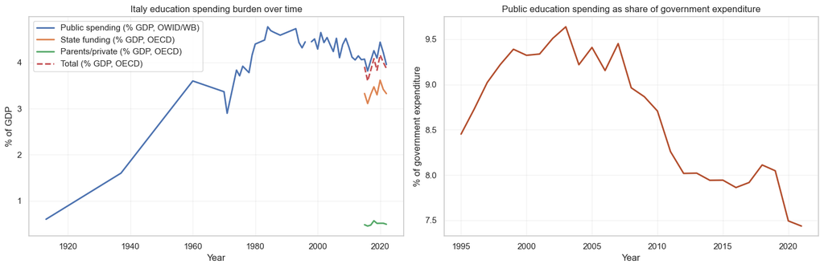

|  | metric | value |
| --- | --- | --- |
| 0 | Latest public spending % GDP (OWID/WB) | 3.96 |
| 1 | Latest public spending % govt expenditure (OWI... | 7.44 |
| 2 | Latest state funding % GDP (OECD) | 3.33 |
| 3 | Latest parents/private funding % GDP (OECD) | 0.49 |
| 4 | Latest total funding % GDP (OECD) | 3.87 |

```python
macro = history.sort_values('year').copy()
latest_macro = macro.loc[macro['year'] == macro['year'].max()]
display(macro.tail(10))

fig, axes = plt.subplots(1, 2, figsize=(15, 5))

axes[0].plot(macro['year'], macro['public_pct_gdp_owid'], label='Public spending (% GDP, OWID/WB)', linewidth=2)
axes[0].plot(macro['year'], macro['state_pct_gdp'], label='State funding (% GDP, OECD)', linewidth=2)
axes[0].plot(macro['year'], macro['parents_private_pct_gdp'], label='Parents/private (% GDP, OECD)', linewidth=2)
axes[0].plot(macro['year'], macro['total_pct_gdp'], label='Total (% GDP, OECD)', linestyle='--', linewidth=2)
axes[0].set_title('Italy education spending burden over time')
axes[0].set_ylabel('% of GDP')
axes[0].legend(loc='best')

axes[1].plot(macro['year'], macro['public_pct_govexp_owid'], color='#b24d2c', linewidth=2)
axes[1].set_title('Public education spending as share of government expenditure')
axes[1].set_ylabel('% of government expenditure')

for ax in axes:
    ax.grid(alpha=0.25)
    ax.set_xlabel('Year')

plt.tight_layout()
plt.show()

macro_summary = pd.DataFrame({
    'metric': [
        'Latest public spending % GDP (OWID/WB)',
        'Latest public spending % govt expenditure (OWID/WB)',
        'Latest state funding % GDP (OECD)',
        'Latest parents/private funding % GDP (OECD)',
        'Latest total funding % GDP (OECD)'
    ],
    'value': [
        macro.loc[macro['public_pct_gdp_owid'].notna(), 'public_pct_gdp_owid'].iloc[-1],
        macro.loc[macro['public_pct_govexp_owid'].notna(), 'public_pct_govexp_owid'].iloc[-1],
        macro.loc[macro['state_pct_gdp'].notna(), 'state_pct_gdp'].iloc[-1],
        macro.loc[macro['parents_private_pct_gdp'].notna(), 'parents_private_pct_gdp'].iloc[-1],
        macro.loc[macro['total_pct_gdp'].notna(), 'total_pct_gdp'].iloc[-1],
    ]
})
display(macro_summary)
```

## 2. Fiscal Surfaces Already Present In The Repo

The inventory makes it explicit that Italy's education fiscal landscape comes from multiple accounting surfaces: OECD macro aggregates, SIOPE school ledgers, MUR school finance and procurement, and university cost-sharing or support files. These are complementary, not perfectly additive.

```python
inventory_top = inventory.sort_values(['source_group', 'latest_year', 'metric']).copy()
display(inventory_top.head(20))

coverage_counts = inventory.groupby(['source_group', 'coverage']).size().reset_index(name='rows')
display(coverage_counts)

headline = inventory[inventory['metric'].isin(['total_pct_gdp', 'parents_private_pct_gdp', 'total_school_expenditure', 'total_expenditures', 'total_awarded_importo', 'avg_tuition_all_students_eur'])].copy()
display(headline[['source_group', 'latest_year', 'metric', 'value', 'unit', 'note']].sort_values(['source_group', 'latest_year']))
```

|  | source_group | source_file | direction | coverage | latest_year | metric | value | unit | note |
| --- | --- | --- | --- | --- | --- | --- | --- | --- | --- |
| 8 | MUR school finance and procurement | BISCONTRATTI202420250921.csv | contracts | school-level | 2024 | rows | 673,976.00 | count | Raw school finance/procurement rows |
| 9 | MUR school finance and procurement | BISCONTRATTI202420250921.csv | contracts | school-level | 2024 | total_awarded_importo | 4,304,585,310.33 | eur | Awarded amount |
| 10 | MUR school finance and procurement | BISCONTRATTI202420250921.csv | contracts | school-level | 2024 | total_gara_importo | 37,192,185,384.97 | eur | Tendered amount |
| 11 | MUR school finance and procurement | BISCONTRATTI202420250921.csv | contracts | school-level | 2024 | unique_regions | 18.00 | count | Unique regions in the file |
| 12 | MUR school finance and procurement | BISCONTRATTI202420250921.csv | contracts | school-level | 2024 | unique_schools | 7,462.00 | count | Unique school codes in the file |
| 0 | MUR school finance and procurement | BISCONSUNTIVO202520251220.csv | entries+expenditures | school-level | 2025 | importo_accertato_impegnato | 4,126,142.32 | eur | Committed/assessed amount |
| 1 | MUR school finance and procurement | BISCONSUNTIVO202520251220.csv | entries+expenditures | school-level | 2025 | importo_da_riscuotere_da_pagare | 1,072,297.83 | eur | Receivable / payable amount |
| 2 | MUR school finance and procurement | BISCONSUNTIVO202520251220.csv | entries+expenditures | school-level | 2025 | importo_riscosso_pagato | 3,053,844.49 | eur | Collected/paid amount |
| 3 | MUR school finance and procurement | BISCONSUNTIVO202520251220.csv | entries+expenditures | school-level | 2025 | rows | 1,067.00 | count | Raw school finance/procurement rows |
| 13 | MUR school finance and procurement | BISPROGANNO202520260320.csv | entries+expenditures | school-level | 2025 | rows | 775,670.00 | count | Raw school finance/procurement rows |
| 4 | MUR school finance and procurement | BISCONSUNTIVO202520251220.csv | entries | school-level | 2025 | total_entries | 6,069,629.99 | eur | Final-account entries |
| 14 | MUR school finance and procurement | BISPROGANNO202520260320.csv | entries | school-level | 2025 | total_entries | 5,328,723,542.64 | eur | Planned budget entries |
| 5 | MUR school finance and procurement | BISCONSUNTIVO202520251220.csv | expenditure | school-level | 2025 | total_expenditures | 5,418,018.45 | eur | Final-account expenditures |
| 15 | MUR school finance and procurement | BISPROGANNO202520260320.csv | expenditure | school-level | 2025 | total_expenditures | 5,335,387,729.39 | eur | Planned budget expenditures |
| 6 | MUR school finance and procurement | BISCONSUNTIVO202520251220.csv | entries+expenditures | school-level | 2025 | unique_regions | 5.00 | count | Unique regions in the file |
| 16 | MUR school finance and procurement | BISPROGANNO202520260320.csv | entries+expenditures | school-level | 2025 | unique_regions | 18.00 | count | Unique regions in the file |
| 7 | MUR school finance and procurement | BISCONSUNTIVO202520251220.csv | entries+expenditures | school-level | 2025 | unique_schools | 11.00 | count | Unique school codes in the file |
| 17 | MUR school finance and procurement | BISPROGANNO202520260320.csv | entries+expenditures | school-level | 2025 | unique_schools | 7,347.00 | count | Unique school codes in the file |
| 18 | MUR tuition and cost sharing | italy_mur_tuition_benchmark_2024.csv | household cost | Totale Italia | 2023-2024 | avg_tuition_all_students_eur | 1,494.61 | eur | MUR 2024 contribuzione e interventi atenei |
| 19 | MUR tuition and cost sharing | italy_mur_tuition_benchmark_2024.csv | household cost | Totale Atenei Statali | 2023-2024 | avg_tuition_all_students_eur | 943.14 | eur | MUR 2024 contribuzione e interventi atenei |

|  | source_group | coverage | rows |
| --- | --- | --- | --- |
| 0 | MUR school finance and procurement | school-level | 18 |
| 1 | MUR tuition and cost sharing | Totale Atenei Statali | 2 |
| 2 | MUR tuition and cost sharing | Totale Italia | 2 |
| 3 | OECD macro education spending | system-wide | 5 |
| 4 | SIOPE school ledgers | school-level | 6 |
| 5 | University student support | regional support bodies | 6 |

|  | source_group | latest_year | metric | value | unit | note |
| --- | --- | --- | --- | --- | --- | --- |
| 9 | MUR school finance and procurement | 2024 | total_awarded_importo | 4,304,585,310.33 | eur | Awarded amount |
| 5 | MUR school finance and procurement | 2025 | total_expenditures | 5,418,018.45 | eur | Final-account expenditures |
| 15 | MUR school finance and procurement | 2025 | total_expenditures | 5,335,387,729.39 | eur | Planned budget expenditures |
| 18 | MUR tuition and cost sharing | 2023-2024 | avg_tuition_all_students_eur | 1,494.61 | eur | MUR 2024 contribuzione e interventi atenei |
| 19 | MUR tuition and cost sharing | 2023-2024 | avg_tuition_all_students_eur | 943.14 | eur | MUR 2024 contribuzione e interventi atenei |
| 22 | OECD macro education spending | 2022 | parents_private_pct_gdp | 0.49 | pct_gdp | Household / private education spending share o... |
| 26 | OECD macro education spending | 2022 | total_pct_gdp | 3.87 | pct_gdp | Total education spending share of GDP |
| 30 | SIOPE school ledgers | 2026 | total_school_expenditure | 1,529,532,466.53 | eur | School expenditure aggregated from 7,959 schoo... |

## 3. Level-Aware Institutional Finance In Real Terms

The new level-aware panel separates Eurostat institutional expenditure by sector and education level, then deflates the values into constant 2022 euros using a World Bank CPI series. The notebook keeps SIOPE school-ledger values and tuition proxies separate because they describe different fiscal surfaces.

| sector | level_label | PRIV | PUBL | TOT_SEC |
| --- | --- | --- | --- | --- |
| 0 | Pre-primary to tertiary education | 5.86 | 80.91 | 86.77 |

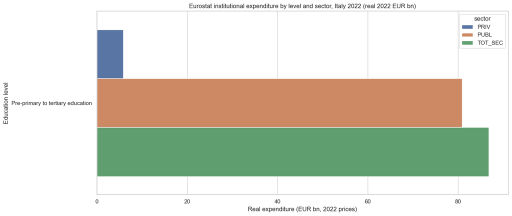

|  | year | nominal_eur | real_base_year_eur | per_student_eur | note |
| --- | --- | --- | --- | --- | --- |
| 32 | 2022 | 51,995,014.12 | 51,995,014.12 | 7.98 | School-ledger expenditure proxy; comparable wi... |
| 33 | 2023 | 125,062,393.80 | 118,405,411.37 | 19.19 | School-ledger expenditure proxy; comparable wi... |
| 34 | 2024 | 357,022,745.42 | 334,730,377.23 | 54.79 | School-ledger expenditure proxy; comparable wi... |
| 35 | 2025 | 658,393,461.13 | NaN | 101.05 | School-ledger expenditure proxy; comparable wi... |
| 36 | 2026 | 274,015,585.68 | NaN | 42.06 | School-ledger expenditure proxy; comparable wi... |

```python
latest_eurostat_year = int(finance.loc[finance['series_group'] == 'eurostat_level_history', 'year'].max())
latest_levels = finance[(finance['series_group'] == 'eurostat_level_history') & (finance['year'] == latest_eurostat_year) & (finance['sector'].isin(['PUBL', 'PRIV', 'TOT_SEC']))].copy()
latest_levels['real_bn_eur_2022'] = bn(latest_levels['real_base_year_eur'])
pivot_levels = latest_levels.pivot_table(index='level_label', columns='sector', values='real_bn_eur_2022', aggfunc='sum').reset_index()
display(pivot_levels.sort_values('TOT_SEC', ascending=False).head(15))

plot_levels = latest_levels.groupby(['level_label', 'sector'], as_index=False)['real_bn_eur_2022'].sum()
plot_levels = plot_levels[plot_levels['level_label'].isin(plot_levels.groupby('level_label')['real_bn_eur_2022'].sum().sort_values(ascending=False).head(8).index)]

plt.figure(figsize=(14, 6))
sns.barplot(data=plot_levels, x='real_bn_eur_2022', y='level_label', hue='sector')
plt.title(f'Eurostat institutional expenditure by level and sector, Italy {latest_eurostat_year} (real 2022 EUR bn)')
plt.xlabel('Real expenditure (EUR bn, 2022 prices)')
plt.ylabel('Education level')
plt.tight_layout()
plt.show()

siope_proxy = finance[finance['series_group'] == 'siope_school_proxy'][['year', 'nominal_eur', 'real_base_year_eur', 'per_student_eur', 'note']].copy()
display(siope_proxy.tail(5))
```

## 4. Household Burden And Tertiary Support

This module combines the macro private-share view with concrete family-facing cost proxies: primary textbook cover prices, estimated secondary annual spending, average university tuition, and regional DSU or ERSU support.

|  | domain | reference_period | segment | indicator | value | unit | min_eur | max_eur | source_file | note |
| --- | --- | --- | --- | --- | --- | --- | --- | --- | --- | --- |
| 0 | macro_household_share | 2022 | system-wide | parents_private_pct_gdp | 0.49 | pct_gdp | NaN | NaN | italy_education_expenditure_state_parents_tren... | Household/private share of GDP devoted to educ... |
| 1 | macro_household_share | 2022 | system-wide | parents_private_share_of_total_pct | 12.68 | pct | NaN | NaN | italy_education_expenditure_state_parents_tren... | Household/private share of total education exp... |
| 2 | household_micro_cost | 2025-2026 | primary | textbook_cover_price_total | NaN | eur | 187.07 | 187.07 | ItalyPrimarySchoolBookExpenses.csv | Official primary textbook total from Ministeri... |
| 3 | household_micro_cost | undated-current | Scuola media (lower secondary) | estimated_mean_annual_household_spending | NaN | eur | 800.00 | 1,200.00 | ItalianMeanSecondarySchoolExpenses.csv | Estimated textbooks plus other materials |
| 4 | household_micro_cost | undated-current | Liceo classico | estimated_mean_annual_household_spending | NaN | eur | 1,000.00 | 1,300.00 | ItalianMeanSecondarySchoolExpenses.csv | Estimated textbooks plus other materials |
| 5 | household_micro_cost | undated-current | Liceo scientifico | estimated_mean_annual_household_spending | NaN | eur | 900.00 | 1,200.00 | ItalianMeanSecondarySchoolExpenses.csv | Estimated textbooks plus other materials |
| 6 | household_micro_cost | undated-current | Liceo linguistico | estimated_mean_annual_household_spending | NaN | eur | 900.00 | 1,200.00 | ItalianMeanSecondarySchoolExpenses.csv | Estimated textbooks plus other materials |
| 7 | household_micro_cost | undated-current | Istituto tecnico | estimated_mean_annual_household_spending | NaN | eur | 800.00 | 1,100.00 | ItalianMeanSecondarySchoolExpenses.csv | Estimated textbooks plus other materials |
| 8 | household_micro_cost | undated-current | Istituto professionale | estimated_mean_annual_household_spending | NaN | eur | 700.00 | 950.00 | ItalianMeanSecondarySchoolExpenses.csv | Estimated textbooks plus other materials |
| 9 | household_micro_cost | undated-current | Overall mean across all secondary schools | estimated_mean_annual_household_spending | NaN | eur | 1,000.00 | 1,000.00 | ItalianMeanSecondarySchoolExpenses.csv | Estimated textbooks plus other materials |
| 10 | household_micro_cost | 2023-2024 | Totale Italia | average_university_tuition_all_students | NaN | eur | 1,494.61 | 1,494.61 | italy_mur_tuition_benchmark_2024.csv | Average university tuition across all enrolled... |
| 11 | household_micro_cost | 2023-2024 | Totale Italia | average_university_tuition_payers | NaN | eur | 2,160.32 | 2,160.32 | italy_mur_tuition_benchmark_2024.csv | Average university tuition among payers only |
| 12 | household_micro_cost | 2023-2024 | Totale Atenei Statali | average_university_tuition_all_students | NaN | eur | 943.14 | 943.14 | italy_mur_tuition_benchmark_2024.csv | Average university tuition across all enrolled... |
| 13 | household_micro_cost | 2023-2024 | Totale Atenei Statali | average_university_tuition_payers | NaN | eur | 1,492.59 | 1,492.59 | italy_mur_tuition_benchmark_2024.csv | Average university tuition among payers only |
| 14 | tertiary_access_buffer | 2023-2024 | national weighted | share_no_contrib_class | 0.01 | share | NaN | NaN | atenei_payment_support_panel_2023_2024.csv | Weighted share of university students in no-co... |
| 15 | tertiary_access_buffer | 2023-2024 | national weighted | share_contrib_up_to_500 | 0.15 | share | NaN | NaN | atenei_payment_support_panel_2023_2024.csv | Weighted share of university students paying a... |
| 16 | tertiary_support | 2024-2025 | national total | spesa_dsu_total | 1,871,127,199.98 | eur | NaN | NaN | dsu_ersu_support_panel_2024_2025.csv | Observed regional DSU/ERSU support expenditure... |
| 17 | tertiary_support | 2024-2025 | national total | support_eur_per_eligible_student | 5,417.18 | eur_per_student | NaN | NaN | dsu_ersu_support_panel_2024_2025.csv | Support expenditure divided by eligible students |
| 18 | tertiary_support | 2024-2025 | national total | support_eur_per_grant_beneficiary | 2,330.32 | eur_per_beneficiary | NaN | NaN | dsu_ersu_support_panel_2024_2025.csv | Support expenditure divided by observed grant ... |

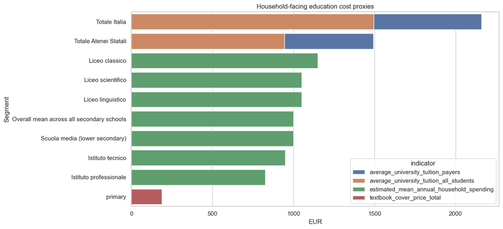

|  | domain | indicator | value | unit | note |
| --- | --- | --- | --- | --- | --- |
| 14 | tertiary_access_buffer | share_no_contrib_class | 0.01 | share | Weighted share of university students in no-co... |
| 15 | tertiary_access_buffer | share_contrib_up_to_500 | 0.15 | share | Weighted share of university students paying a... |
| 16 | tertiary_support | spesa_dsu_total | 1,871,127,199.98 | eur | Observed regional DSU/ERSU support expenditure... |
| 17 | tertiary_support | support_eur_per_eligible_student | 5,417.18 | eur_per_student | Support expenditure divided by eligible students |
| 18 | tertiary_support | support_eur_per_grant_beneficiary | 2,330.32 | eur_per_beneficiary | Support expenditure divided by observed grant ... |

```python
display(household)

micro_costs = household[household['domain'] == 'household_micro_cost'].copy()
micro_costs['mid_eur'] = micro_costs[['min_eur', 'max_eur']].mean(axis=1)
micro_costs = micro_costs[micro_costs['mid_eur'].notna()]

plt.figure(figsize=(13, 6))
sns.barplot(data=micro_costs.sort_values('mid_eur', ascending=False), x='mid_eur', y='segment', hue='indicator', dodge=False)
plt.title('Household-facing education cost proxies')
plt.xlabel('EUR')
plt.ylabel('Segment')
plt.tight_layout()
plt.show()

support_rows = household[household['domain'].isin(['tertiary_access_buffer', 'tertiary_support'])][['domain', 'indicator', 'value', 'unit', 'note']].copy()
display(support_rows)
```

## 5. Territorial Funding-Risk Proxy

The territorial panel joins regional school stocks and outcome indicators to named regional tertiary support spending. It does not claim to be a full regional school-expenditure panel. The funding side is explicitly a DSU or ERSU proxy because the available SIOPE regional pivots are not yet reliable enough for a direct named join.

|  | region_name | neet_count_15_29_thousands | neet_risk_index | school_students_total | estimated_bes_share_pct | estimated_disabled_share_pct | upper_secondary_repeaters_pct | dsu_total_spend_eur | dsu_spend_per_eligible_eur | dsu_total_spend_eur_bn |
| --- | --- | --- | --- | --- | --- | --- | --- | --- | --- | --- |
| 6 | Lazio | 124.84 | 0.71 | 645393 | 10.16 | 4.35 | 4.50 | 215,843,117.86 | 5,357.64 | 0.22 |
| 3 | Campania | 236.99 | 2.25 | 731294 | 4.16 | 4.29 | 5.60 | 206,601,334.43 | 4,206.82 | 0.21 |
| 14 | Sicilia | 196.35 | 1.69 | 567060 | 4.60 | 4.36 | 5.70 | 172,552,517.89 | 5,750.79 | 0.17 |
| 12 | Puglia | 131.19 | 0.80 | 446228 | 5.35 | 4.32 | 5.20 | 171,006,169.75 | 7,400.62 | 0.17 |
| 4 | Emilia-Romagna | 60.85 | -0.16 | 502534 | 0.00 | 4.35 | 6.60 | 166,409,231.75 | 5,630.68 | 0.17 |
| 8 | Lombardia | 150.13 | 1.06 | 1107414 | 12.69 | 4.41 | 5.90 | 160,743,085.39 | 4,254.94 | 0.16 |
| 11 | Piemonte | 58.86 | -0.19 | 451341 | 11.97 | 4.37 | 5.60 | 143,400,356.61 | 5,694.11 | 0.14 |
| 17 | Veneto | 64.78 | -0.11 | 532543 | 8.78 | 4.37 | 5.50 | 107,563,787.86 | 4,609.15 | 0.11 |
| 2 | Calabria | 74.72 | 0.03 | 215293 | 4.11 | 4.33 | 5.40 | 105,995,157.17 | 6,977.96 | 0.11 |
| 15 | Toscana | 56.41 | -0.22 | 398412 | 12.23 | 4.32 | 6.90 | 95,054,314.08 | 5,351.86 | 0.10 |

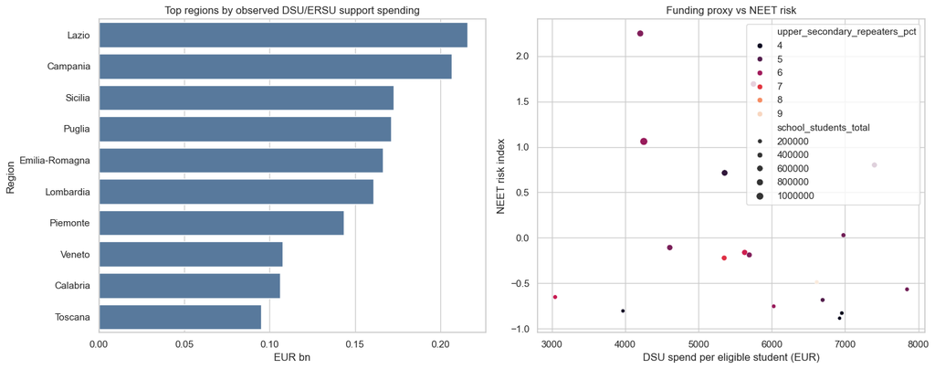

```python
territorial_rank = territorial[['region_name', 'neet_count_15_29_thousands', 'neet_risk_index', 'school_students_total', 'estimated_bes_share_pct', 'estimated_disabled_share_pct', 'upper_secondary_repeaters_pct', 'dsu_total_spend_eur', 'dsu_spend_per_eligible_eur']].copy()
territorial_rank['dsu_total_spend_eur_bn'] = bn(territorial_rank['dsu_total_spend_eur'])
display(territorial_rank.sort_values('dsu_total_spend_eur', ascending=False).head(10))

fig, axes = plt.subplots(1, 2, figsize=(15, 6))
top_support = territorial_rank.sort_values('dsu_total_spend_eur', ascending=False).head(10)
sns.barplot(data=top_support, x='dsu_total_spend_eur_bn', y='region_name', ax=axes[0], color='#4C78A8')
axes[0].set_title('Top regions by observed DSU/ERSU support spending')
axes[0].set_xlabel('EUR bn')
axes[0].set_ylabel('Region')

sns.scatterplot(data=territorial_rank, x='dsu_spend_per_eligible_eur', y='neet_risk_index', size='school_students_total', hue='upper_secondary_repeaters_pct', ax=axes[1], palette='rocket')
axes[1].set_title('Funding proxy vs NEET risk')
axes[1].set_xlabel('DSU spend per eligible student (EUR)')
axes[1].set_ylabel('NEET risk index')

plt.tight_layout()
plt.show()
```

## 6. Save The Children Validation Layer

The earlier workspace file used a PDF-only extraction. This section rebuilds the usable subset from local official data:

- **INVALSI** validates the lower-secondary Italian and math under-threshold shares.
- **ISTAT** supplies the official local early-school-leaver rate, but the local file currently stops at 2020 rather than the PDF's 2021 label.
- **Archipelago learning-gain claims** remain PDF-only program-evaluation statements and are kept outside the validated evidence tier.

```python
invalsi_it = invalsi_trend[(invalsi_trend['GRADO'] == 'Terza Secondaria di Primo Grado') & (invalsi_trend['Ripartizione'] == 'Italia') & (invalsi_trend['MATERIA'].isin(['Italiano', 'Matematica']))].copy()

invalsi_it['below_minimum_2022'] = 100 - invalsi_it['Perc.2022']

invalsi_it['below_minimum_2024'] = 100 - invalsi_it['Perc.2024']

display(invalsi_it[['MATERIA', 'Perc.2022', 'below_minimum_2022', 'Perc.2024', 'below_minimum_2024']])



for col in ['ITTER107', 'CITTADINANZA', 'CONDIZIONE_PROF', 'SESSO', 'TIPO_DATO', 'TIME_PERIOD', 'OBS_VALUE']:

    istat_esl[col] = pd.to_numeric(istat_esl[col], errors='coerce') if col != 'ITTER107' else istat_esl[col].astype(str)



istat_rate = istat_esl[

    (istat_esl['ITTER107'] == 'IT')

    & (istat_esl['CITTADINANZA'] == 9)

    & (istat_esl['CONDIZIONE_PROF'] == 99)

    & (istat_esl['SESSO'] == 9)

    & (istat_esl['TIPO_DATO'] == 29)

].copy()

istat_rate = istat_rate.sort_values('TIME_PERIOD')

display(istat_rate[['TIME_PERIOD', 'OBS_VALUE']].tail(10))



pdf_lookup = save_children_pdf.set_index('indicator')['value'].to_dict()

below_it_2022 = float(invalsi_it.loc[invalsi_it['MATERIA'] == 'Italiano', 'below_minimum_2022'].iloc[0])

below_math_2022 = float(invalsi_it.loc[invalsi_it['MATERIA'] == 'Matematica', 'below_minimum_2022'].iloc[0])



if istat_rate.empty:

    esl_latest_local_year = np.nan

    esl_latest_local_value = np.nan

    esl_note = 'No local ISTAT early-school-leaver rate rows matched the expected filter in this checkout.'

else:

    esl_latest_local_year = int(istat_rate['TIME_PERIOD'].max())

    esl_latest_local_value = float(istat_rate.loc[istat_rate['TIME_PERIOD'] == esl_latest_local_year, 'OBS_VALUE'].iloc[0])

    esl_note = 'Local ISTAT official rate is available through 2020 in this checkout; it is close in level but does not directly reproduce the PDF\'s 2021 timestamp.'



validation_rows = [

    {

        'indicator': 'students_below_minimum_italian_lower_secondary_pct',

        'pdf_value': pdf_lookup.get('students_below_minimum_italian_lower_secondary_pct'),

        'local_validated_value': below_it_2022,

        'local_reference_year': 2022,

        'validation_status': 'validated_from_local_invalsi',

        'validation_note': 'Computed as 100 minus INVALSI share reaching the target in Italian for grade 8, Italy, 2022.'

    },

    {

        'indicator': 'students_below_minimum_math_lower_secondary_pct',

        'pdf_value': pdf_lookup.get('students_below_minimum_math_lower_secondary_pct'),

        'local_validated_value': below_math_2022,

        'local_reference_year': 2022,

        'validation_status': 'validated_from_local_invalsi',

        'validation_note': 'Computed as 100 minus INVALSI share reaching the target in mathematics for grade 8, Italy, 2022.'

    },

    {

        'indicator': 'early_school_leavers_18_24_pct',

        'pdf_value': pdf_lookup.get('early_school_leavers_18_24_pct'),

        'local_validated_value': esl_latest_local_value,

        'local_reference_year': esl_latest_local_year,

        'validation_status': 'partially_validated_local_official_latest_available' if not np.isnan(esl_latest_local_value) else 'not_validated_local_missing',

        'validation_note': esl_note

    },

    {

        'indicator': 'archipelago_learning_gain_math_months',

        'pdf_value': pdf_lookup.get('archipelago_learning_gain_math_months'),

        'local_validated_value': np.nan,

        'local_reference_year': np.nan,

        'validation_status': 'pdf_only_program_claim',

        'validation_note': 'No local official dataset in the repo independently reproduces this program-evaluation claim.'

    },

    {

        'indicator': 'archipelago_learning_gain_italian_months',

        'pdf_value': pdf_lookup.get('archipelago_learning_gain_italian_months'),

        'local_validated_value': np.nan,

        'local_reference_year': np.nan,

        'validation_status': 'pdf_only_program_claim',

        'validation_note': 'No local official dataset in the repo independently reproduces this program-evaluation claim.'

    },

]



validation = pd.DataFrame(validation_rows)

validation['gap_pdf_minus_local'] = validation['pdf_value'] - validation['local_validated_value']

display(validation)

validation.to_csv(PROC / 'save_the_children_validation_panel.csv', index=False)

print('Wrote:', PROC / 'save_the_children_validation_panel.csv')
```

|  | MATERIA | Perc.2022 | below_minimum_2022 | Perc.2024 | below_minimum_2024 |
| --- | --- | --- | --- | --- | --- |
| 22 | Italiano | 61.43 | 38.57 | 60.14 | 39.86 |
| 23 | Matematica | 56.37 | 43.63 | 55.96 | 44.04 |

|  | TIME_PERIOD | OBS_VALUE |
| --- | --- | --- |
| 1243 | 2011 | 17.80 |
| 1244 | 2012 | 17.30 |
| 1245 | 2013 | 16.80 |
| 1246 | 2014 | 15.00 |
| 1247 | 2015 | 14.70 |
| 1248 | 2016 | 13.80 |
| 1249 | 2017 | 14.00 |
| 1250 | 2018 | 14.50 |
| 1251 | 2019 | 13.50 |
| 1252 | 2020 | 13.10 |

|  | indicator | pdf_value | local_validated_value | local_reference_year | validation_status | validation_note | gap_pdf_minus_local |
| --- | --- | --- | --- | --- | --- | --- | --- |
| 0 | students_below_minimum_italian_lower_secondary... | 39.00 | 38.57 | 2,022.00 | validated_from_local_invalsi | Computed as 100 minus INVALSI share reaching t... | 0.43 |
| 1 | students_below_minimum_math_lower_secondary_pct | 44.00 | 43.63 | 2,022.00 | validated_from_local_invalsi | Computed as 100 minus INVALSI share reaching t... | 0.37 |
| 2 | early_school_leavers_18_24_pct | 12.70 | 13.10 | 2,020.00 | partially_validated_local_official_latest_avai... | Local ISTAT official rate is available through... | -0.40 |
| 3 | archipelago_learning_gain_math_months | 2.00 | NaN | NaN | pdf_only_program_claim | No local official dataset in the repo independ... | NaN |
| 4 | archipelago_learning_gain_italian_months | 3.50 | NaN | NaN | pdf_only_program_claim | No local official dataset in the repo independ... | NaN |

```
Wrote: c:\Users\Dell\Documents\VSC Projects\Italienation\local_data\processed\save_the_children_validation_panel.csv
```

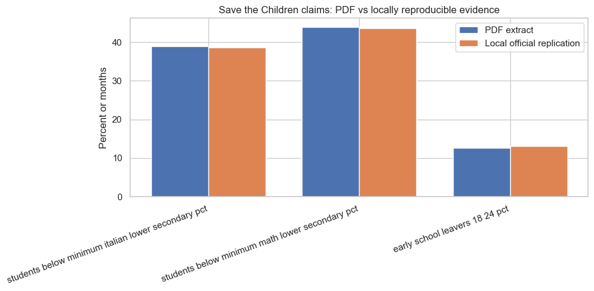

```python
validated_only = validation[validation['validation_status'].isin(['validated_from_local_invalsi', 'partially_validated_local_official_latest_available'])].copy()
plt.figure(figsize=(10, 5))
plot_df = validated_only.dropna(subset=['local_validated_value']).copy()
plot_df['label'] = plot_df['indicator'].str.replace('_', ' ', regex=False)
x = np.arange(len(plot_df))
width = 0.38
plt.bar(x - width / 2, plot_df['pdf_value'], width=width, label='PDF extract')
plt.bar(x + width / 2, plot_df['local_validated_value'], width=width, label='Local official replication')
plt.xticks(x, plot_df['label'], rotation=20, ha='right')
plt.ylabel('Percent or months')
plt.title('Save the Children claims: PDF vs locally reproducible evidence')
plt.legend()
plt.tight_layout()
plt.show()
```

## 7. Analytical Bottom Line

The main fiscal story is now well covered locally: Italy's macro public expenditure history, public versus household split, school-ledger flows, higher-education cost sharing, regional tertiary support, and current household burden proxies are all reproducible from workspace data.

For Save the Children, the notebook now treats only the locally reproducible INVALSI-based and ISTAT-based indicators as evidence-tier inputs. The Archipelago learning-gain figures remain visible for reference, but they should not be cited as validated local data until an independent underlying dataset is added to the repo.